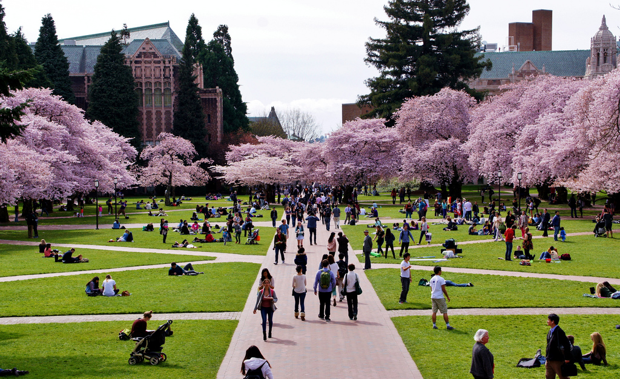

### What data does this site show?

This website uses the grade distributions from all University of Washington classes between 2010 and 2016. This data is used to give students insights about their classes and professors beyond the course evaluation catalog and ratemyprofessor.com

### Where does this data come from?

All grade data was obtained by Austin Walters via FOIA request for Easy A, a student advising website. Visit easy-a.net for more information. This data contains over 30,000 classes information from UW.

### What is the Freedom of Information Act (FIOA)?

The FOIA is a law signed by Lyndon B Johnson in 1966 that states that federal agencies must allow the public to request records for any reason. Since the University of Washington is a public university, the FOIA allows us to request grade data as long as the data requested does not violate the privacy of any student. This means that we can obtain grade distributions, but not a specific student’s grades.

### Can I predict how well I will do in my courses?

The short answer is yes. The long answer is you can definitely make a prediction, but it may not be fully accurate. We will be able to give you the average grade that the past students got in certain course. You also will be able to check the class size that best fit for your interest.

### Will the data cover 2016-2017 school year?

Unfortunately, the grade from 2016-2017 has not been release yet.

### Can I share this website to my friend?

You’re more than welcome to share this website to your friends, classmates, family members.

### Who should I contact if I have future comment/question about this website?

This website is created by 5 students in INFO 201 Spring 2017. You can email any of our team members.  
Baochau Tran (English, Vietnamese): bc1212@uw.edu  
Zubin Chopra (English): zubinc@uw.edu  
Yuwen Kuang (English, Chinese): kuangy3@uw.edu  
Yuan Qu (English, Chinese): quyuan0522@yahoo.com  
Jacob Kernan Siegelman (English): jacsieg@uw.edu